# 统计模拟及软件实现论文

## 8.6

### 8.6.1检验广告方案、广告媒体及其交互作用对销售量的影响是否显著

```r
load("C:/exercise/ch8/exercise8_6.RData")
exercise8_6
```

```
##    广告方案 广告媒体 销售量
## 1         A     报纸      8
## 2         A     报纸     12
## 3         A     电视     12
## 4         A     电视      8
## 5         B     报纸     22
## 6         B     报纸     14
## 7         B     电视     26
## 8         B     电视     30
## 9         C     报纸     10
## 10        C     报纸     18
## 11        C     电视     18
## 12        C     电视     14
```

```r
data8_6=data.frame(exercise8_6)
names(data8_6)=c("p","m","n")#p="广告方案"m="广告媒体"n="销售数量"
data8_6
```

```
##    p    m  n
## 1  A 报纸  8
## 2  A 报纸 12
## 3  A 电视 12
## 4  A 电视  8
## 5  B 报纸 22
## 6  B 报纸 14
## 7  B 电视 26
## 8  B 电视 30
## 9  C 报纸 10
## 10 C 报纸 18
## 11 C 电视 18
## 12 C 电视 14
```

```r
fit<-aov(n~p*m,data8_6)
summary(fit)
```

```
##             Df Sum Sq Mean Sq F value Pr(>F)
## p            2    344     172   10.75 0.0104 *
## m            1     48      48    3.00 0.1340
## p:m          2     56      28    1.75 0.2519
## Residuals    6     96      16
## ---
## Signif. codes:  0 '***' 0.001 '**' 0.01 '*' 0.05 '.' 0.1 ' ' 1
```

```r
fit$coefficients
```

```
##  (Intercept)           pB           pC        m电视     pB:m电视
##  1.00000e+01  8.00000e+00  4.00000e+00 -2.56395e-15  1.00000e+01
##     pC:m电视
##  2.00000e+00
```

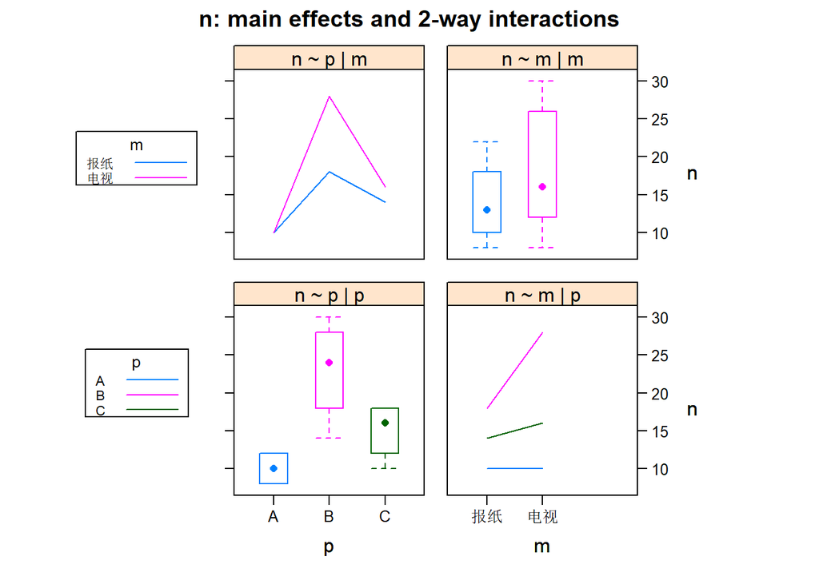

```r
library(HH)
interaction2wt(n~p+m,data=data8_6)
```

### 8.6.2 计算偏效应量并进行分析

```r
model_2wi=aov(n~p+m+p*m,data=data8_6)
library(DescTools)
EtaSq(model_2wi,anova=T)
```

```
##               eta.sq eta.sq.part  SS df  MS     F          p
## p         0.63235294   0.7818182 344  2 172 10.75 0.01038618
## m         0.08823529   0.3333333  48  1  48  3.00 0.13397460
## p:m       0.10294118   0.3684211  56  2  28  1.75 0.25193177
## Residuals 0.17647059          NA  96  6  16    NA         NA
```

# 9

## 9.1

### 9.1.1绘制散点图，判断人均GDP与居民消费水平之间的关系，并计算相关系数分析其关系强度

```r
load("C:/exercise/ch9/exercise9_1.RData")
library(car)
```

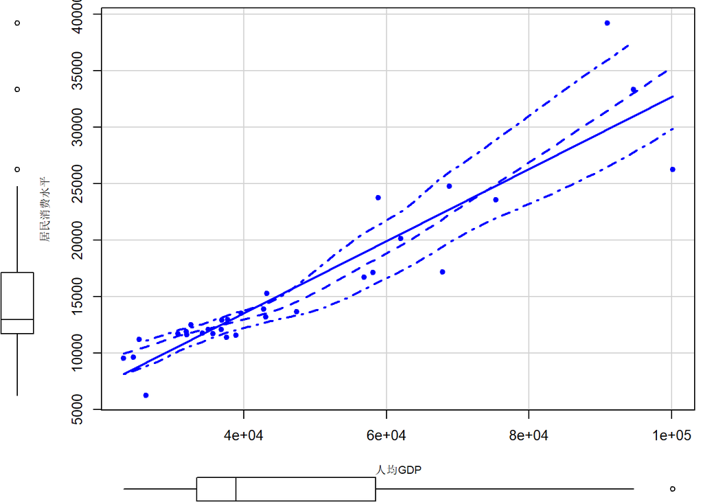

```r
par(mai=c(.8,.8,.1,.1),cex=.8)
scatterplot(居民消费水平~人均GDP,data=exercise9_1,pch=19,xlab="人均GDP",ylab="居民消费水平",cex.lab=0.8)
```

```r
cor(exercise9_1[,2],exercise9_1[,3])
```

```
## [1] 0.9240374
```

```r
library(psych)
cor.test(exercise9_1[,2],exercise9_1[,3])#相关系数为0.924接近于，即认为居民消费水平和人均GDP相关性很强
```

```
##
##  Pearson's product-moment correlation
##
## data:  exercise9_1[, 2] and exercise9_1[, 3]
## t = 13.016, df = 29, p-value = 1.227e-13
## alternative hypothesis: true correlation is not equal to 0
## 95 percent confidence interval:
##  0.8470371 0.9630517
## sample estimates:
##       cor
## 0.9240374
```

### 9.1.2 以居民消费水平为因变量、人均GDP为自变量建立回归模型，并对回归模型进行综合评估

```r
load("C:/exercise/ch9/exercise9_1.RData")
model<-lm(居民消费水平~人均GDP,data=exercise9_1)
summary(model)
```

```
##
## Call:
## lm(formula = 居民消费水平 ~ 人均GDP, data = exercise9_1)
##
## Residuals:
##     Min      1Q  Median      3Q     Max
## -6462.7 -1330.4   133.7  1083.7  9409.5
##
## Coefficients:
##              Estimate Std. Error t value Pr(>|t|)
## (Intercept) 7.514e+02  1.268e+03   0.592    0.558
## 人均GDP     3.194e-01  2.454e-02  13.016 1.23e-13 ***
## ---
## Signif. codes:  0 '***' 0.001 '**' 0.01 '*' 0.05 '.' 0.1 ' ' 1
##
## Residual standard error: 2819 on 29 degrees of freedom
## Multiple R-squared:  0.8538, Adjusted R-squared:  0.8488
## F-statistic: 169.4 on 1 and 29 DF,  p-value: 1.227e-13
```

```r
confint(model,level=0.95)
```

```
##                     2.5 %       97.5 %
## (Intercept) -1842.7681829 3345.6541085
## 人均GDP         0.2692021    0.3695731
```

```r
anova(model)
```

```
## Analysis of Variance Table
##
## Response: 居民消费水平
##           Df     Sum Sq    Mean Sq F value    Pr(>F)
## 人均GDP    1 1346327123 1346327123  169.42 1.227e-13 ***
## Residuals 29  230454442    7946705
## ---
## Signif. codes:  0 '***' 0.001 '**' 0.01 '*' 0.05 '.' 0.1 ' ' 1
```

## 9.2

### 9.2.1绘制产量与生产费用之间的散点图，判断二者之间的关系形态

[figure not shown]

```r
load("C:/exercise/ch9/exercise9_2.RData")
library(car)
par(mai=c(.8,.8,.1,.1),cex=.8)
scatterplot(产量~生产费用,data=exercise9_2,pch=19,xlab="产量",ylab="生产费用",cex.lab=0.8)
```

### 9.2.2 计算二者线性相关系数，对相关系数显著性进行检验

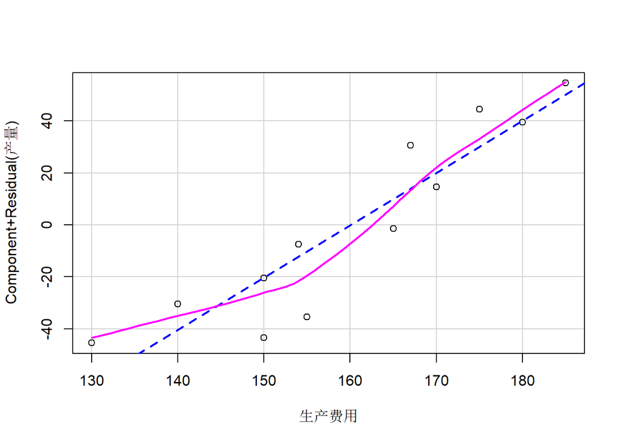

```r
load("C:/exercise/ch9/exercise9_2.RData")
model<-lm(产量~生产费用,data=exercise9_2)
library(car)
crPlots(model)
```

```r
cor(exercise9_2[,2],exercise9_2[,3])
```

```
## [1] 0.9202324
```

```r
library(psych)
cor.test(exercise9_2[,2],exercise9_2[,3])
```

```
##
##  Pearson's product-moment correlation
##
## data:  exercise9_2[, 2] and exercise9_2[, 3]
## t = 7.4355, df = 10, p-value = 2.222e-05
## alternative hypothesis: true correlation is not equal to 0
## 95 percent confidence interval:
##  0.7339428 0.9777578
## sample estimates:
##       cor
## 0.9202324
```

## 9.3

### 9.3.1 用航班准点率做自变量，顾客投诉次数为因变量的估计回归方程

```r
load("C:/exercise/ch9/exercise9_3.RData")
model<-lm(投诉次数~航班准点率,data=exercise9_3)
summary(model)
```

```
##
## Call:
## lm(formula = 投诉次数 ~ 航班准点率, data = exercise9_3)
##
## Residuals:
##     Min      1Q  Median      3Q     Max
## -24.678 -11.412  -2.078  16.322  24.615
##
## Coefficients:
##             Estimate Std. Error t value Pr(>|t|)
## (Intercept) 430.1892    72.1548   5.962 0.000337 ***
## 航班准点率   -4.7006     0.9479  -4.959 0.001108 **
## ---
## Signif. codes:  0 '***' 0.001 '**' 0.01 '*' 0.05 '.' 0.1 ' ' 1
##
## Residual standard error: 18.89 on 8 degrees of freedom
## Multiple R-squared:  0.7545, Adjusted R-squared:  0.7239
## F-statistic: 24.59 on 1 and 8 DF,  p-value: 0.001108
```

### 9.3.2 回归系数的显著性

```r
confint(model,level=0.95)
```

```
##                  2.5 %     97.5 %
## (Intercept) 263.799891 596.578574
## 航班准点率   -6.886469  -2.514776
```

```r
anova(model)
```

```
## Analysis of Variance Table
##
## Response: 投诉次数
##            Df Sum Sq Mean Sq F value   Pr(>F)
## 航班准点率  1 8772.6  8772.6  24.592 0.001108 **
## Residuals   8 2853.8   356.7
## ---
## Signif. codes:  0 '***' 0.001 '**' 0.01 '*' 0.05 '.' 0.1 ' ' 1
```

```r
# t=-4.959,P=0.001108<0.05,拒绝原假设，即认为投诉次数和航班准点率之间线性关系显著
```

### 9.3.3 估计准点率为80%时，顾客的投诉次数

```r
# 回归直线方程为：y=-4.7006x+430.1892
# 将X=80代入得，y=54.1412
```

## 9.4 用广告费支出作为自变量x，销售额作为因变量y建立回归模型，并对模型进行诊断和评价

```r
load("C:/exercise/ch9/exercise9_4.RData")
model<-lm(销售额~广告费支出,data=exercise9_4)
summary(model)
```

```
##
## Call:
## lm(formula = 销售额 ~ 广告费支出, data = exercise9_4)
##
## Residuals:
##        1        2        3        4        5        6        7
## -11.9466  -0.4941   8.4110   1.3160   7.1261   1.9362  -6.3487
##
## Coefficients:
##             Estimate Std. Error t value Pr(>|t|)
## (Intercept)  29.3991     4.8073   6.116  0.00169 **
## 广告费支出    1.5475     0.4635   3.339  0.02058 *
## ---
## Signif. codes:  0 '***' 0.001 '**' 0.01 '*' 0.05 '.' 0.1 ' ' 1
##
## Residual standard error: 7.878 on 5 degrees of freedom
## Multiple R-squared:  0.6903, Adjusted R-squared:  0.6284
## F-statistic: 11.15 on 1 and 5 DF,  p-value: 0.02058
```

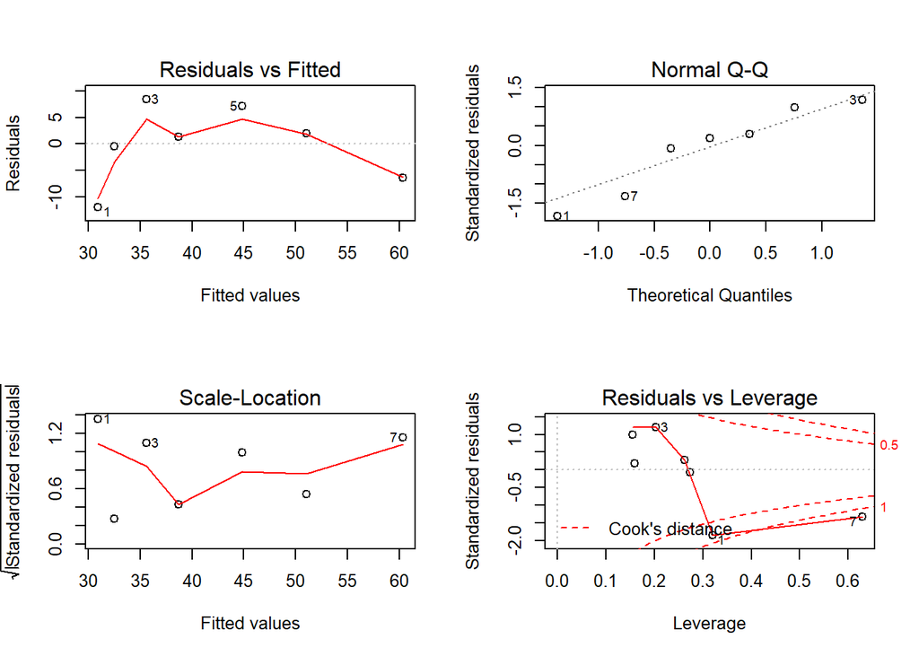

```r
par(mfrow=c(2,2),cex=0.8,cex.main=0.7)
plot(model)
```

# 10

## 10.1

### 10.1.1 用电视广告费用和报纸广告费用做自变量，建立估计的回归方程，说明其回归系数的意义

```r
load("C:/exercise/ch10/exercise10_1.RData")
model1<-lm(月销售收入~电视广告费用+报纸广告费用,data=exercise10_1)
summary(model1)
```

```
##
## Call:
## lm(formula = 月销售收入 ~ 电视广告费用 + 报纸广告费用, data = exercise10_1)
##
## Residuals:
##      1      2      3      4      5      6      7      8
## -6.325 -4.124  6.577 -2.080  6.061 -2.380 -4.197  6.469
##
## Coefficients:
##              Estimate Std. Error t value Pr(>|t|)
## (Intercept)  832.3009    15.7387  52.882 4.57e-08 ***
## 电视广告费用   2.2902     0.3041   7.532 0.000653 ***
## 报纸广告费用   1.3010     0.3207   4.057 0.009761 **
## ---
## Signif. codes:  0 '***' 0.001 '**' 0.01 '*' 0.05 '.' 0.1 ' ' 1
##
## Residual standard error: 6.426 on 5 degrees of freedom
## Multiple R-squared:  0.919,  Adjusted R-squared:  0.8866
## F-statistic: 28.38 on 2 and 5 DF,  p-value: 0.001865
```

### 10.1.2 对回归模型做综合评价

```r
confint(model,level=0.95)
```

[output not shown]

```r
anova(model1)
```

```
## Analysis of Variance Table
##
## Response: 月销售收入
##              Df  Sum Sq Mean Sq F value   Pr(>F)
## 电视广告费用  1 1664.01 1664.01  40.299 0.001432 **
## 报纸广告费用  1  679.53  679.53  16.457 0.009761 **
## Residuals     5  206.46   41.29
## ---
## Signif. codes:  0 '***' 0.001 '**' 0.01 '*' 0.05 '.' 0.1 ' ' 1
```

### 10.1.3 给定电视广告费用30万元，报纸广告费用20万元，求月销售收入95%的置信区间和预测区间

```r
predict(model1,data.frame(电视广告费用=30,报纸广告费用=20),interval="confidence",level=0.95)
```

```
##        fit      lwr      upr
## 1 927.0262 919.4121 934.6403
```

```r
predict(model1,data.frame(电视广告费用=30,报纸广告费用=20),interval="prediction",level=0.95)
```

```
##        fit      lwr      upr
## 1 927.0262 908.8376 945.2148
```

## 10.2 某农场通过试验取得早稻收获量与春季降雨量和春季温度数据如下

```r
load("C:/exercise/ch10/exercise10_2.RData")
model2<-lm(收获量~降雨量+温度,data=exercise10_2)
summary(model2)
```

```
##
## Call:
## lm(formula = 收获量 ~ 降雨量 + 温度, data = exercise10_2)
##
## Residuals:
##        1        2        3        4        5        6        7
## -275.101   90.464  216.483  140.280  150.676 -316.599   -6.203
##
## Coefficients:
##             Estimate Std. Error t value Pr(>|t|)
## (Intercept)   -0.591    505.004  -0.001   0.9991
## 降雨量        22.387      9.601   2.332   0.0801 .
## 温度         327.672     98.798   3.317   0.0295 *
## ---
## Signif. codes:  0 '***' 0.001 '**' 0.01 '*' 0.05 '.' 0.1 ' ' 1
##
## Residual standard error: 261.4 on 4 degrees of freedom
## Multiple R-squared:  0.9913, Adjusted R-squared:  0.987
## F-statistic: 228.4 on 2 and 4 DF,  p-value: 7.532e-05
```

### 10.2.2 比较降雨量和温度在预测收获量中的相对重要性

```r
library(lm.beta)
model2.beta<-lm.beta(model2)
summary(model2.beta)
```

```
##
## Call:
## lm(formula = 收获量 ~ 降雨量 + 温度, data = exercise10_2)
##
## Residuals:
##        1        2        3        4        5        6        7
## -275.101   90.464  216.483  140.280  150.676 -316.599   -6.203
##
## Coefficients:
##             Estimate Standardized Std. Error t value Pr(>|t|)
## (Intercept)  -0.5910       0.0000   505.0042  -0.001   0.9991
## 降雨量       22.3865       0.4146     9.6005   2.332   0.0801 .
## 温度        327.6717       0.5896    98.7979   3.317   0.0295 *
## ---
## Signif. codes:  0 '***' 0.001 '**' 0.01 '*' 0.05 '.' 0.1 ' ' 1
##
## Residual standard error: 261.4 on 4 degrees of freedom
## Multiple R-squared:  0.9913, Adjusted R-squared:  0.987
## F-statistic: 228.4 on 2 and 4 DF,  p-value: 7.532e-05
```

## 10.3

### 10.3.1 用不良贷款做因变量，建立多元线性回归模型

```r
load("C:/exercise/ch10/exercise10_3.RData")
model1<-lm(不良贷款~贷款余额+应收贷款+贷款项目个数+固定资产投资,data=exercise10_3)
summary(model1)
```

```
##
## Call:
## lm(formula = 不良贷款 ~ 贷款余额 + 应收贷款 + 贷款项目个数 +
##     固定资产投资, data = exercise10_3)
##
## Residuals:
##     Min      1Q  Median      3Q     Max
## -2.9198 -0.9507 -0.2880  1.0334  3.1037
##
## Coefficients:
##              Estimate Std. Error t value Pr(>|t|)
## (Intercept)  -1.02164    0.78237  -1.306  0.20643
## 贷款余额      0.04004    0.01043   3.837  0.00103 **
## 应收贷款      0.14803    0.07879   1.879  0.07494 .
## 贷款项目个数  0.01453    0.08303   0.175  0.86285
## 固定资产投资 -0.02919    0.01507  -1.937  0.06703 .
## ---
## Signif. codes:  0 '***' 0.001 '**' 0.01 '*' 0.05 '.' 0.1 ' ' 1
##
## Residual standard error: 1.779 on 20 degrees of freedom
## Multiple R-squared:  0.7976, Adjusted R-squared:  0.7571
## F-statistic:  19.7 on 4 and 20 DF,  p-value: 1.035e-06
```

### 10.3.2 分析模型中是否存在共线性

```r
load("C:/exercise/ch10/exercise10_3.RData")
model1<-lm(不良贷款~贷款余额+应收贷款+贷款项目个数+固定资产投资,data=exercise10_3)
library(car)
vif(model1)
```

```
##     贷款余额     应收贷款 贷款项目个数 固定资产投资
##     5.330807     1.889860     3.834823     2.781220
```

```r
1/vif(model1)
```

```
##     贷款余额     应收贷款 贷款项目个数 固定资产投资
##    0.1875889    0.5291397    0.2607682    0.3595545
```